# HW1 Peer Assessment

# Part A. ANOVA

Additional Material: ANOVA tutorial

https://datascienceplus.com/one-way-anova-in-r/

You are thinking about starting a new business. However, your initial capital is limited. To start, you are thinking about a pizza business but you are open to explore options with lower initial investments. For this, you collected the following data on initial investment for several types of industries:

Pizza Bakery Shoes Gifts Pets 80 150 48 100 25 125 40 35 96 80 35 120 95 35 30 58 75 45 99 35 110 160 75 75 30 140 60 115 150 28 97 45 42 45 20 50 100 78 100 75 65 86 65 120 48 79 87 125 50 20

## Question A1 - 6 pts

The ANOVA table for the model above (with several missing values) is:

| Variability Source | DF | SS | Mean SS | F-stat | Pr(>F) |
| --- | --- | --- | --- | --- | --- |
| Treatments |  | 18186 |  |  | 0.00662 |
| Error. |  |  | 1114 |  |  |
| Total |  | 68336 |  |  |  |

Filling in the incomplete ANOVA table…

```r
# manually transforming data into long format
data_a1 = read.csv("data/hw_a1_anova_data.csv",sep = ",",header = TRUE)
data_a1 %>% head()
```

```
##   business investment
## 1    pizza         80
## 2    pizza        125
## 3    pizza         35
## 4    pizza         58
## 5    pizza        110
## 6    pizza        140
```

```r
# run anova
a1_anova <- aov(investment ~ business, data = data_a1)
summary(a1_anova)
```

```
##             Df Sum Sq Mean Sq F value  Pr(>F)
## business     4  18186    4546    4.08 0.00662 **
## Residuals   45  50150    1114
## ---
## Signif. codes:  0 '***' 0.001 '**' 0.01 '*' 0.05 '.' 0.1 ' ' 1
```

The complete ANOVA table is shown below.

[output not shown]

## Question A2 - 2 pts

*State the null and the alternative hypothesis.*

- **Null Hypothesis (H0):** The mean investment is the same across all business categories
- **Alternative Hypothesis (H1):** The mean investment is not the same across all business categories

## Question A3 - 1 pts

*Under H0, the F-test statistic has what type of distribution?*

The F-test statistic follows the F-distribution.

## Question A4 - 2 pts

Your only criterion for choosing a line of business is selecting the one with the lowest initial investment. Based on the ANOVA table above, should you be indifferent when choosing his next line of business?

Assuming a statistical significant level of alpha = 0.05, we reject the null hypothesis since the p-value is < 0.05, indicating that there is significant evidence that the mean investment is not the same across all business categories. Therefore, it wouldn’t be wise to be indifferent when choosing the next line of business.

# Part B. Simple Linear Regression

Perform linear regressions on a dataset from a European Toyota car dealer on the sales records of used cars (Toyota Corolla). We would like to construct a reasonable linear regression model for the relationship between the sales prices of used cars and various explanatory variables (such as age, mileage, horsepower). We are interested to see what factors affect the sales price of a used car and by how much.

Data Description

*Id* - ID number of each used car *Model* - Model name of each used car *Price* - The price (in Euros) at which each used car was sold *Age* - Age (in months) of each used car as of August 2004 *KM* - Accumulated kilometers on odometer *HP* - Horsepower *Metallic* - Metallic color? (Yes = 1, No = 0) *Automatic* - Automatic transmission? ( Yes = 1, No = 0) *CC* - Cylinder volume (in cubic centimeters) *Doors* - Number of doors *Gears* - Number of gears *Weight* - Weight (in kilograms)

The data is in the file “UsedCars.csv”. To read the data in `R`, save the file in your working directory (make sure you have changed the directory if different from the R working directory) and read the data using the `R` function `read.csv()`.

Read data and show few rows of data.

```r
# Read in the data
data_b = read.csv("data/UsedCars.csv",sep = ",",header = TRUE)
# Show the first few rows of data
head(data, 3)
```

[output not shown]

## Question B1: Exploratory Data Analysis - 9 pts

1. **3 pts** Use a scatter plot to describe the relationship between Price and the Accumulated kilometers on odometer. Describe the general trend (direction and form). Include plots and R-code used.

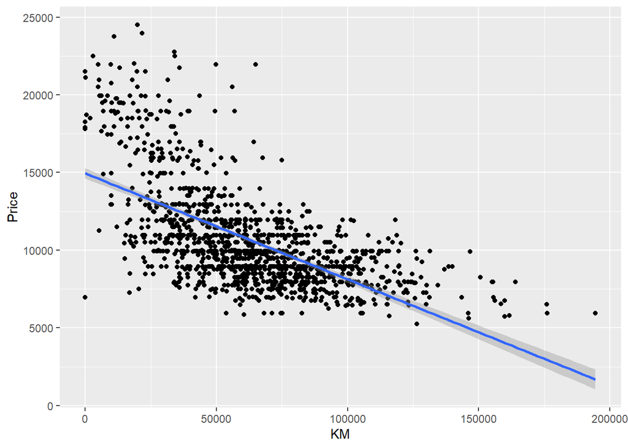

```r
ggplot(data_b, aes(x = KM, y = Price)) +
  geom_point() +
  geom_smooth(method = "lm", se = TRUE)
```

There’s a negative downward slope trend between price and accumulated kilometers. The higher the accumulated kilometers, the less the car costs.

2. **3 pts** What is the value of the correlation coefficient between *Price* and *KM*? Please interpret the strength of the correlation based on the correlation coefficient.

```r
b1_model <- lm(Price ~ KM, data = data_b)
summary(b1_model)
```

```
##
## Call:
## lm(formula = Price ~ KM, data = data_b)
##
## Residuals:
##    Min     1Q Median     3Q    Max
##  -7993  -1774   -457   1394  11437
##
## Coefficients:
##               Estimate Std. Error t value Pr(>|t|)
## (Intercept)  1.494e+04  1.693e+02   88.24   <2e-16 ***
## KM          -6.817e-02  2.439e-03  -27.95   <2e-16 ***
## ---
## Signif. codes:  0 '***' 0.001 '**' 0.01 '*' 0.05 '.' 0.1 ' ' 1
##
## Residual standard error: 2615 on 1262 degrees of freedom
## Multiple R-squared:  0.3824, Adjusted R-squared:  0.3819
## F-statistic: 781.4 on 1 and 1262 DF,  p-value: < 2.2e-16
```

The R-squared value is 0.3824. Also, the relationship between Price and KM is negative. Therefore, the correlation coefficient is the negative of the square root value of R-squared, or **-0.618**.

The correlation coefficient ranges from -1 to 1. Therefore, a coeffieint of -0.618 indicates that there is a moderate negative correlation between KM and Price.

3. **2 pts** Based on this exploratory analysis, would you recommend a simple linear regression model for the relationship?

Just based on the exploratory analysis above, a simple linear regression *could* be a good starting point for modeling the relationship between KM and Price. However, further diagnostic may need to be done, because this may not be the *best* model.

4. **1 pts** Based on the analysis above, would you pursue a transformation of the data? *Do not transform the data.*

## Question B2: Fitting the Simple Linear Regression Model - 11 pts

Fit a linear regression model, named *model_1*, to evaluate the relationship between UsedCars Price and the accumulated KM. *Do not transform the data.* The function you should use in R is:

```r
# Your code here...
model_1 <- lm(Price ~ KM, data = data_b)
summary(model_1)
```

```
##
## Call:
## lm(formula = Price ~ KM, data = data_b)
##
## Residuals:
##    Min     1Q Median     3Q    Max
##  -7993  -1774   -457   1394  11437
##
## Coefficients:
##               Estimate Std. Error t value Pr(>|t|)
## (Intercept)  1.494e+04  1.693e+02   88.24   <2e-16 ***
## KM          -6.817e-02  2.439e-03  -27.95   <2e-16 ***
## ---
## Signif. codes:  0 '***' 0.001 '**' 0.01 '*' 0.05 '.' 0.1 ' ' 1
##
## Residual standard error: 2615 on 1262 degrees of freedom
## Multiple R-squared:  0.3824, Adjusted R-squared:  0.3819
## F-statistic: 781.4 on 1 and 1262 DF,  p-value: < 2.2e-16
```

1. **3 pts** What are the model parameters and what are their estimates?
- **Intercept**: $14,940 - The price of a used car when the KM driven is zero.
- **KM**: -0.06817 - The change in price for every KM driven.
2. **2 pts** Write down the estimated simple linear regression equation.

Price = 14,940 - 0.06817 * KM

3. **2 pts** Interpret the estimated value of the $\beta_1$ parameter in the context of the problem.

Beta_1 (KM) is -0.06817. The negative sign indicates that there is an inverse relationship between the number of KM driven and the car’s price. So, as KM increases, the price decreases. And for every 1 KM driven, the price of the car decreases by $0.06817.

4. **2 pts** Find a 95% confidence interval for the $\beta_1$ parameter. Is $\beta_1$ statistically significant at this level?

```r
confint(model_1, "KM", level = 0.95)
```

```
##          2.5 %      97.5 %
## KM -0.07296019 -0.06339078
```

Based on the interval above, and the low p-value (<2e-16), the Beta_1 coefficient is statistically significant at this level.

5. **2 pts** Is $\beta_1$ statistically significantly negative at an $\alpha$-level of 0.01? What is the approximate p-value of this test?

```r
confint(model_1, "KM", level = 0.01)
```

```
##         49.5 %      50.5 %
## KM -0.06820606 -0.06814491
```

The p-value of Beta_1 coefficient is very low (<2e-16), much smaller than 0.01. Therefore, we can confidently say that the relationship between KM and Price is inverse; that is, for each KM driven, the price of a car decreases.

## Question B3: Checking the Assumptions of the Model - 8 pts

Create and interpret the following graphs with respect to the assumptions of the linear regression model. In other words, comment on whether there are any apparent departures from the assumptions of the linear regression model. Make sure that you state the model assumptions and assess each one. Each graph may be used to assess one or more model assumptions.

1. **2 pts** Scatterplot of the data with *KM* on the x-axis and *Price* on the y-axis

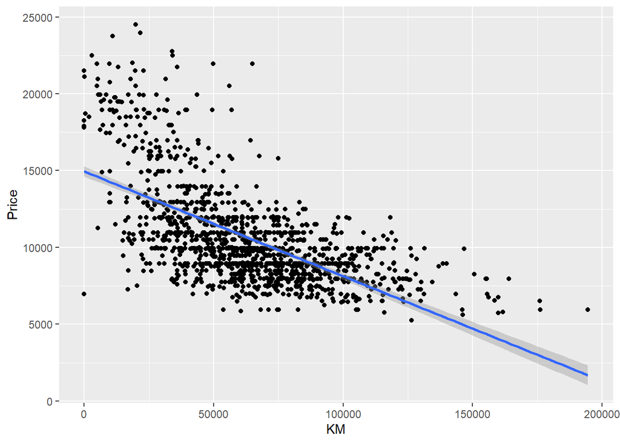

```r
ggplot(data_b, aes(x = KM, y = Price)) +
  geom_point() +
  geom_smooth(method = "lm", se = TRUE)
```

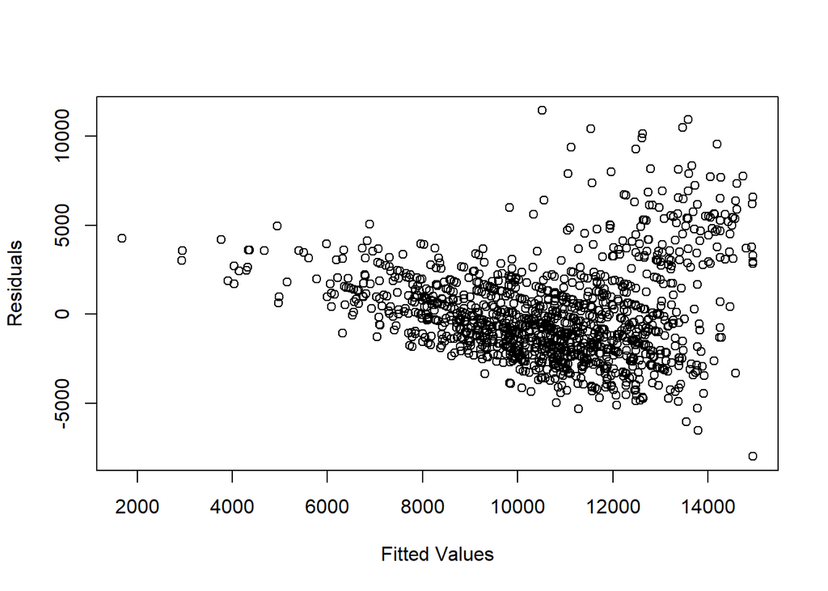

```r
plot(
  x = model_1$fitted.values,
  y = model_1$residuals,
  xlab = "Fitted Values",
  ylab = "Residuals"
)
```

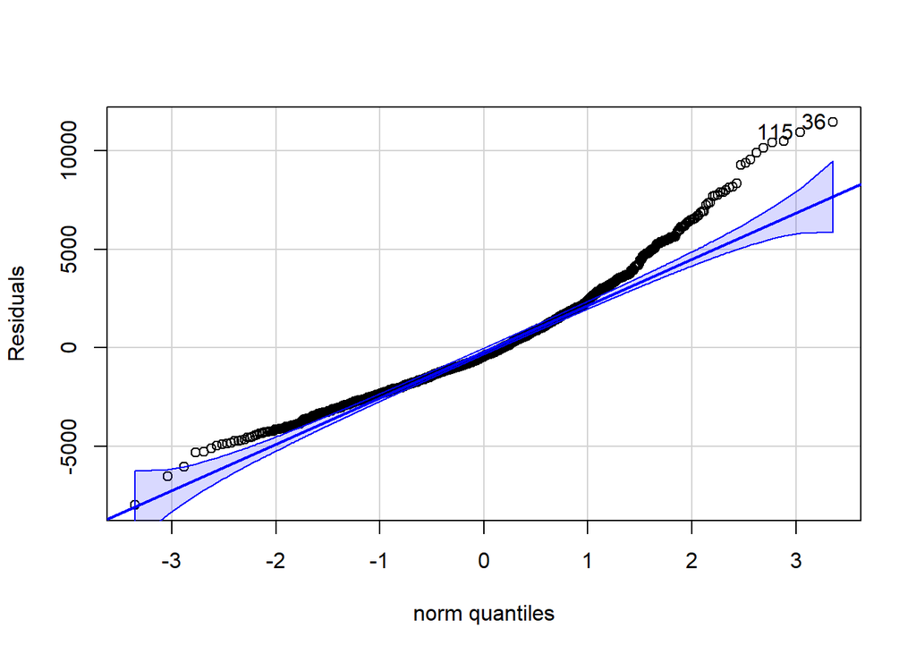

```
## [1]  36 115
```

```r
qqPlot(model_1$residuals, ylab = "Residuals")
```

- **Model Assumption(s) it checks**: normality
- **Interpretation**: If the points follow the line, the residuals are normally distributed. This does not appear to be true for the tails of the plot, namely the upper tail where there is a higher deviation, which indicates the data may not normally distributed.

## Question B4: Improving the Fit - 10 pts

1. **2 pts** Use a Box-Cox transformation (`boxCox()`) in `car()` package or (`boxcox()`) in `MASS()` package to find the optimal $\lambda$ value rounded to the nearest half integer. What transformation of the response, if any, does it suggest to perform?

```r
boxcox <- boxCox(model_1)
```

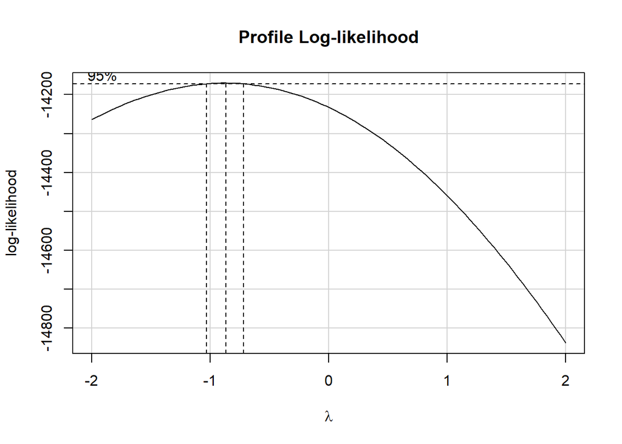

```r
optimal_lambda <- boxcox$x[which.max(boxcox$y)]
print(optimal_lambda)
```

```
## [1] -0.8686869
```

The optimal lambda value for the Box-Cox transformation is -0.8686869. Rounded to the nearest half-integer, it is -1.

2. **2 pts** Create a linear regression model, named *model_2*, that uses the inverse transformed *Price* as the response, and the *KM* as the predictor. Hint: Use the inverse transformation Price^(opt.lambda).

```r
model_2 <- lm(Price^-1 ~ KM, data = data_b)
summary(model_2)
```

```
##
## Call:
## lm(formula = Price^-1 ~ KM, data = data_b)
##
## Residuals:
##        Min         1Q     Median         3Q        Max
## -5.691e-05 -1.498e-05 -2.690e-07  1.276e-05  7.692e-05
##
## Coefficients:
##              Estimate Std. Error t value Pr(>|t|)
## (Intercept) 6.696e-05  1.284e-06   52.16   <2e-16 ***
## KM          5.464e-10  1.849e-11   29.55   <2e-16 ***
## ---
## Signif. codes:  0 '***' 0.001 '**' 0.01 '*' 0.05 '.' 0.1 ' ' 1
##
## Residual standard error: 1.983e-05 on 1262 degrees of freedom
## Multiple R-squared:  0.409,  Adjusted R-squared:  0.4085
## F-statistic: 873.2 on 1 and 1262 DF,  p-value: < 2.2e-16
```

3. **2 pts** Compare the R-squared values of *model_1* and *model_2*. Did the transformation improve the explanatory power of the model?
- **R-squared of Model 1:** 0.3824
- **R-squared of Model 2:** 0.4090

The R-squared value increased in Model 2, so the transformation improved the explanatory power of the model.

4. **4 pts** Similar to Question B3, assess and interpret all model assumptions of *model_2*. A model is considered a good fit if all assumptions hold. Based on your interpretation of the model assumptions, is *model_2* a good fit?

Below is the scatterplot. Linearity and constant variance seems to be improved with the new model.

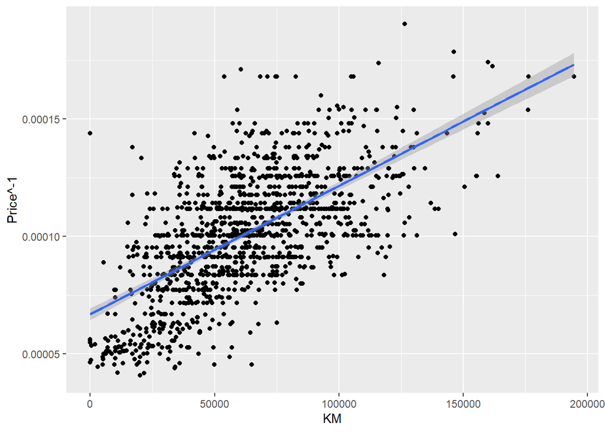

```r
ggplot(data_b, aes(x = KM, y = Price^-1)) +
  geom_point() +
  geom_smooth(method = "lm", se = TRUE)
```

Below is the residual plot. Linearity and constant variance also seems to be improved here. The values appear to be scattered more randomly, indicating improved independence.

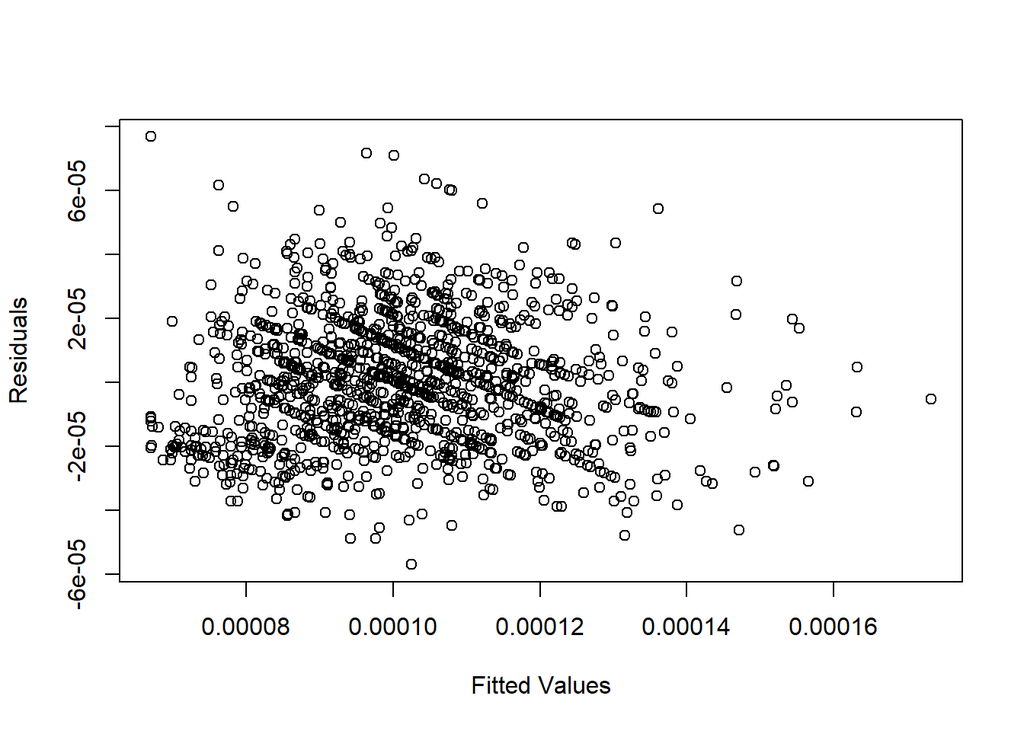

```r
plot(
  x = model_2$fitted.values,
  y = model_2$residuals,
  xlab = "Fitted Values",
  ylab = "Residuals"
)
```

Below is the Q-Q Plot. Normality is greatly improved here as well.

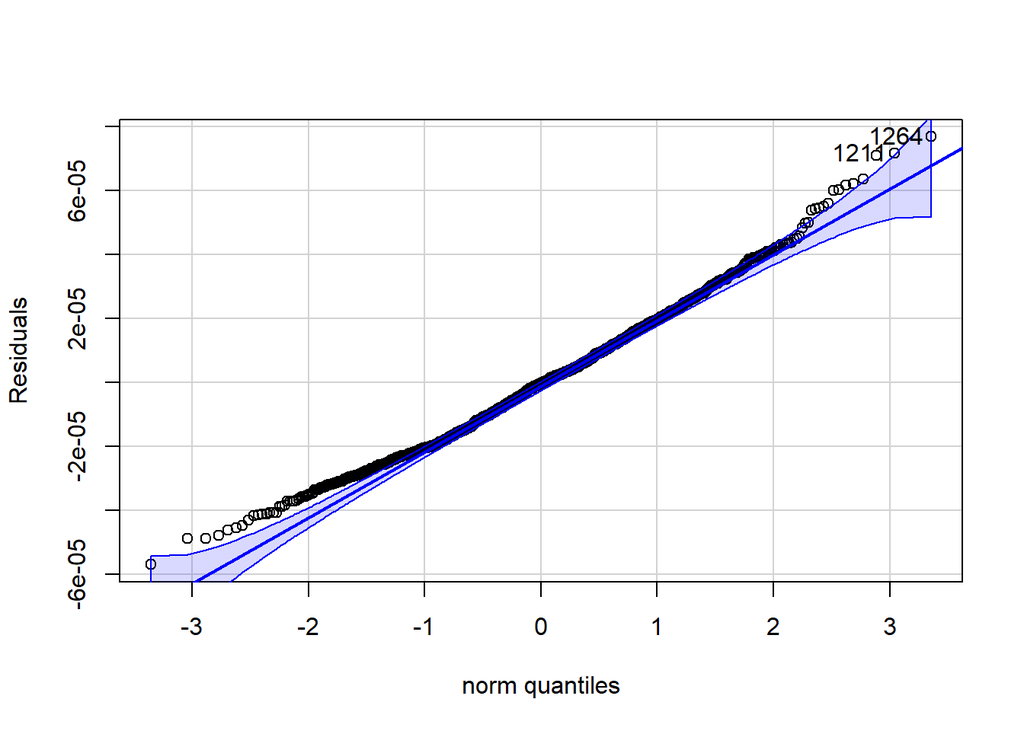

```
## [1] 1264 1211
```

```r
qqPlot(model_2$residuals, ylab = "Residuals")
```

Based on these diagnostics, Model 2 appears to be a better fit for the model.

## Question B5: Prediction - 3 pts

Use the results from both model_1 and model_2 with a better fit to discuss the effects of certain independent variables on the dependent variable: Holding everything else equal, how much the sales price would decrease if a car accumulated 10,000 more kilometers? What observations can you make about the result in the context of the problem?

**Model 1**: linear

- Original Price = Beta_0
- Original Price = $14,940
- New Price = Beta_0 + Beta_KM * KM
- New Price = 14,940 - 0.06817 * 10,000
- New Price = $14,258.30
- Change in Price = 14,258.30 - 14,940
- Change in Price = **-$681.7**

**Model 2**: transformed; assuming lambda = -1

- 1/New Price = Beta_0 + Beta_KM * KM
- 1/New Price = 6.696e-05 + 5.464e-10 * 10,000
- 1/New Price = 6.696e-05 + 5.464e-06
- 1/New Price = 7.2424e-05
- New Price = $13,807.58
- 1/Original Price = Beta_0
- 1/Original Price = 6.696e-05
- Original Price = $14,934.29
- Change in Price = 13,807.58 - 14,934.29
- Change in Price = **-$1,126.71**

Using Model 2 means that accumulated KM has a greater impact in the used car sales price.

# Part C. ANOVA - 8 pts

We are going compare the two models (the full regression with all independent variables versus the new model with only the independent variables that are significant). Run a linear regression of Price on the all independent variables call it model_full & again run a linear regression of Price on only the independent variables that are significant, call it model_reduced . Use the summary() function to show the regression results.

```r
model_full <- lm(Price ~ Age + KM + HP + Metallic + Automatic + CC + Doors + Gears + Weight, data = data_b)
summary(model_full)
```

```
##
## Call:
## lm(formula = Price ~ Age + KM + HP + Metallic + Automatic + CC +
##     Doors + Gears + Weight, data = data_b)
##
## Residuals:
##     Min      1Q  Median      3Q     Max
## -8117.5  -771.5   -50.0   701.0  6403.5
##
## Coefficients:
##               Estimate Std. Error t value Pr(>|t|)
## (Intercept) -2.883e+03  1.505e+03  -1.916 0.055649 .
## Age         -1.299e+02  2.610e+00 -49.782  < 2e-16 ***
## KM          -1.465e-02  1.441e-03 -10.162  < 2e-16 ***
## HP           2.540e+01  3.376e+00   7.524 1.01e-13 ***
## Metallic    -2.281e+01  7.436e+01  -0.307 0.759059
## Automatic    4.991e+02  1.497e+02   3.334 0.000881 ***
## CC          -5.259e-03  8.499e-02  -0.062 0.950667
## Doors        1.315e+01  4.086e+01   0.322 0.747638
## Gears        6.281e+02  1.927e+02   3.259 0.001148 **
## Weight       1.504e+01  1.300e+00  11.567  < 2e-16 ***
## ---
## Signif. codes:  0 '***' 0.001 '**' 0.01 '*' 0.05 '.' 0.1 ' ' 1
##
## Residual standard error: 1227 on 1254 degrees of freedom
## Multiple R-squared:  0.8649, Adjusted R-squared:  0.8639
## F-statistic: 891.8 on 9 and 1254 DF,  p-value: < 2.2e-16
```

Insignificant variables include: Metallic, CC, Doors. Below is the model with only significant variables.

```r
model_reduced <- lm(Price ~ Age + KM + HP + Automatic + Gears + Weight, data = data_b)
summary(model_reduced)
```

```
##
## Call:
## lm(formula = Price ~ Age + KM + HP + Automatic + Gears + Weight,
##     data = data_b)
##
## Residuals:
##     Min      1Q  Median      3Q     Max
## -8193.8  -772.8   -47.9   703.3  6402.3
##
## Coefficients:
##               Estimate Std. Error t value Pr(>|t|)
## (Intercept) -2.930e+03  1.498e+03  -1.956 0.050666 .
## Age         -1.299e+02  2.600e+00 -49.942  < 2e-16 ***
## KM          -1.463e-02  1.439e-03 -10.170  < 2e-16 ***
## HP           2.527e+01  3.294e+00   7.671  3.4e-14 ***
## Automatic    4.930e+02  1.476e+02   3.341 0.000861 ***
## Gears        6.139e+02  1.876e+02   3.272 0.001098 **
## Weight       1.519e+01  1.202e+00  12.637  < 2e-16 ***
## ---
## Signif. codes:  0 '***' 0.001 '**' 0.01 '*' 0.05 '.' 0.1 ' ' 1
##
## Residual standard error: 1226 on 1257 degrees of freedom
## Multiple R-squared:  0.8648, Adjusted R-squared:  0.8642
## F-statistic:  1341 on 6 and 1257 DF,  p-value: < 2.2e-16
```

1. **2 pts** Retrieve and compare the R-squared and Adjusted R-Squared from the two models (the full regression vs the reduced model). Discuss your findings with regard to the relative magnitudes of the R-squared and the Adjusted R-Squared from the two models and what they imply.
- **Full Model**: R-squared of 0.8649, Adjusted R-squared of 0.8639
- **Reduced Model**: R-squared of 0.8648, Adjusted R-squared of 0.8642

These values are very close to one another despite the reduced model having less variables. These are both good R-square values that indicate strong models, although the reduced one doesn’t include the variables that are not statistically significant.

2. **3 pts** Perform an ANOVA F-test on the full model and the reduced model. Using an $\alpha$-level of 0.05, can we reject the null hypothesis that the means of the car attributes are equal? Please interpret.

```r
anova(model_reduced, model_full)
```

```
## Analysis of Variance Table
##
## Model 1: Price ~ Age + KM + HP + Automatic + Gears + Weight
## Model 2: Price ~ Age + KM + HP + Metallic + Automatic + CC + Doors + Gears +
##     Weight
##   Res.Df        RSS Df Sum of Sq     F Pr(>F)
## 1   1257 1888962181
## 2   1254 1888677611  3    284570 0.063 0.9793
```

The p-value of the F-test result is 0.9793, which is much greater than the alpha level of 0.05. This means that we fail to reject the null hypothesis; as in, there is no statistically significant evidence to suggest that the model_full is a better fit than model_reduced. So, the extra (insignificant) variables do not statistically contribute to explaining the variation in car prices compared to the reduced model.

3. **3 pts** Suppose we are interested in predicting Price when HP = 192, rest of the variables as 1. Please make a prediction using both model_full and model_reduced and provide the 95% prediction interval of each prediction on the original scale of the response, price. What observations can you make about the result in the context of the problem?

```r
# define new df for model_full
data_predict_full <- data.frame(
  Age = 1,
  KM = 1,
  HP = 192,
  Metallic = 1,
  Automatic = 1,
  CC = 1,
  Doors = 1,
  Gears = 1,
  Weight = 1
)

# define new df for model_reduced
data_preduct_reduced <- data_predict_full %>% select(-Metallic, -CC, -Doors)

# predict price of model_full
predict(model_full,    data_predict_full,    interval = "prediction", level = 0.95)
```

```
##        fit       lwr      upr
## 1 2996.578 -1232.607 7225.763
```

```r
# predict price of model_reduced
predict(model_reduced, data_preduct_reduced, interval = "prediction", level = 0.95)
```

```
##        fit       lwr     upr
## 1 2914.038 -1269.575 7097.65
```

These results are quite similar, indicating that the exclusion of the statistically insignificant variables do not highly impact the results. The difference between the lower and upper bands are also quite large for both models, though that could be due to the artificial data points.